# Assignment_2

Yixuan Li_u7457310

2022-10-30

Github website.https://github.com/Lexie1xx1/Assignment_2_Yixuan.git

Here are the packages required for this assignment:

```r
library(tidyverse)
library(pacman)
library(metafor)
library(orchaRd)
library(flextable)
```

Read the data and rename them.

```r
OA <- read_csv("./data/OA_activitydat_20190302_BIOL3207.csv")
```

```
## ──────────────────────────────────────────────────────── Delimiter: "," chr
## (5): loc, species, treatment, size, comment dbl (4): ...1, animal_id, sl,
## activity
```

```r
clark <- read_csv("./data/clark_paper_data.csv")
```

### Q1: Correct analysis of Clark et al. (2020) data (i.e., OA_activitydat_20190302_BIOL3207.csv) to generate the summary statistics (means, SD, N) for each of the fish species’ average activity for each treatment.

Summary statistics (mean, SD, N) were generated for the average activity of each fish species under each treatment.

```r
## Calculate and exclude erroneous data
summary_data <-OA %>% group_by(species, treatment) %>%
              summarise(mean = mean(activity, na.rm = TRUE),
                        sd = sd(activity, na.rm = TRUE),
                        n = length(unique(animal_id))) %>%
              rename(Species = "species")
```

### Q2: Through coding, merge the summary statistics generated from 1) with the metadata (i.e., clark_paper_data.csv) from Clark et al. (2020).

```r
## Combine the data
total_data <- cbind(clark, summary_data)
```

### Q3: Through coding, correctly merge the combined summary statistics and metadata from Clark et al. (2020) (output from 1 & 2) into the larger meta-analysis dataset (i.e., ocean_meta_data.csv).

```r
## Expand the data
final <- pivot_wider(total_data, names_from = treatment,
                     names_glue = "{treatment}_{.value}",
                     values_from = c("mean", "sd", "n"))

ocean <- read_csv("./data/ocean_meta_data.csv")
## Displays the number of row and column of the data
dim(ocean)
```

```
## [1] 818  22
```

```r
dim(final)
```

```
## [1]  6 22
```

```r
## Do some renaming of colnames so they match ocean
final_1 <- final %>% rename("oa.mean" = CO2_mean,
                            "oa.sd" = CO2_sd,
                            "oa.n" = CO2_n,
                            "ctrl.mean" = control_mean,
                            "ctrl.sd" = control_sd,
                            "ctrl.n" = control_n)

# Reorder col names based on names in ocean
final_1 <- final_1[names(ocean)]

# Check columns are in same order
colnames(ocean) == colnames(final_1)
```

```
##  [1] TRUE TRUE TRUE TRUE TRUE TRUE TRUE TRUE TRUE TRUE TRUE TRUE TRUE TRUE TRUE
## [16] TRUE TRUE TRUE TRUE TRUE TRUE TRUE
```

```r
# Combine the data
full_data <- rbind(ocean, final_1)
```

Delete the NA values.

```r
missing <- sum(is.na(full_data))
missing
```

```
## [1] 6
```

```r
full_1 <- full_data[complete.cases(full_data),]
```

### Q4: Correctly calculate the log response ratio (lnRR) effect size for every row of the dataframe using metafor’s escalc() function.

```r
## Calculate the log response ratio (lnRR) effect size
lnRR_data <- metafor::escalc(measure = "ROM", m1i = ctrl.mean, m2i = oa.mean, sd1i = ctrl.sd, sd2i =  oa.sd, n1i = ctrl.n, n2i = oa.n, data = full_1, var.names = c("lnRR", "V_lnRR"))
```

Increase a row of observations.

```r
full <-  lnRR_data %>% mutate(residual = 1:n())
```

### Q5: Correct meta-analytic model fitted to the data that controls for the sampling variance of lnRR. The model should include a random effect of study and observation. Use metafor’s rma.mv() function.

```r
## Multi-level meta-analytic model
MLMA <- metafor::rma.mv(lnRR~1,V=V_lnRR, random = list(~1|Study, ~1|residual), method = "REML", test = "t", dfs = "contain", data=full)
MLMA
```

```
##
## Multivariate Meta-Analysis Model (k = 795; method: REML)
##
## Variance Components:
##
##             estim    sqrt  nlvls  fixed    factor
## sigma^2.1  0.4792  0.6922     91     no     Study
## sigma^2.2  4.0497  2.0124    795     no  residual
##
## Test for Heterogeneity:
## Q(df = 794) = 736088678.9542, p-val < .0001
##
## Model Results:
##
## estimate      se     tval  df    pval    ci.lb   ci.ub
##  -0.1273  0.1140  -1.1162  90  0.2673  -0.3539  0.0993
##
## ---
## Signif. codes:  0 '***' 0.001 '**' 0.01 '*' 0.05 '.' 0.1 ' ' 1
```

It can be seen that the p-value is 0.2673, which is a large number, so there is no significant difference between the mean values of the control group and the experimental group in each study.

### Q6: Written paragraph of the findings and what they mean which is supported with a figure. The paragraph should include:

1. Correct presentation and interpretation of overall meta-analytic mean and measures of uncertainty around the mean estimate (e.g., 95% confidence intervals).

```r
## Convert the overall meta-analytic mean back to the correlation coefficient
predict(MLMA, transf = "transf.ztor")
```

[output not shown]

2. Measures of heterogeneity in effect size estimates across studies (i.e., I2 and/or prediction intervals - see predict() function in metafor).

```r
## Calculate I2
i2_vals <- orchaRd::i2_ml(MLMA)

## Collate different I2 values
i2 <- tibble(type = firstup(gsub("I2_", "", names(i2_vals))), I2 = i2_vals)

## Now let's make a neat table
flextable(i2) %>%
    align(part = "header", align = "center") %>%
    compose(part = "header", j = 1, value = as_paragraph(as_b("Type"))) %>%
    compose(part = "header", j = 2, value = as_paragraph(as_b("I"), as_b(as_sup("2")),
        as_b("(%)")))
```

| Type | I2(%) |
| --- | --- |
| Total | 100.00000 |
| Study | 10.58073 |
| Residual | 89.41927 |

3. Forest plot showing the mean estimate, 95% confidence interval, and prediction interval with clearly labelled axes, number of samples and studies plotted on figure.

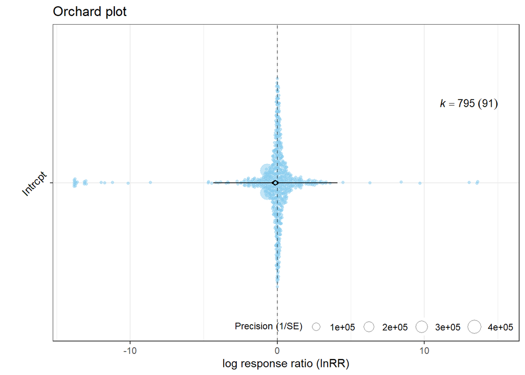

```r
# Make an orchard plot using the model object
orchaRd::orchard_plot(MLMA, mod = "1", group = "Study", data = full,
    xlab = "log response ratio (lnRR)", angle = 45)+ labs(title = "Orchard plot")
```

### Q7: Funnel plot for visually assessing the possibility of publication bias.

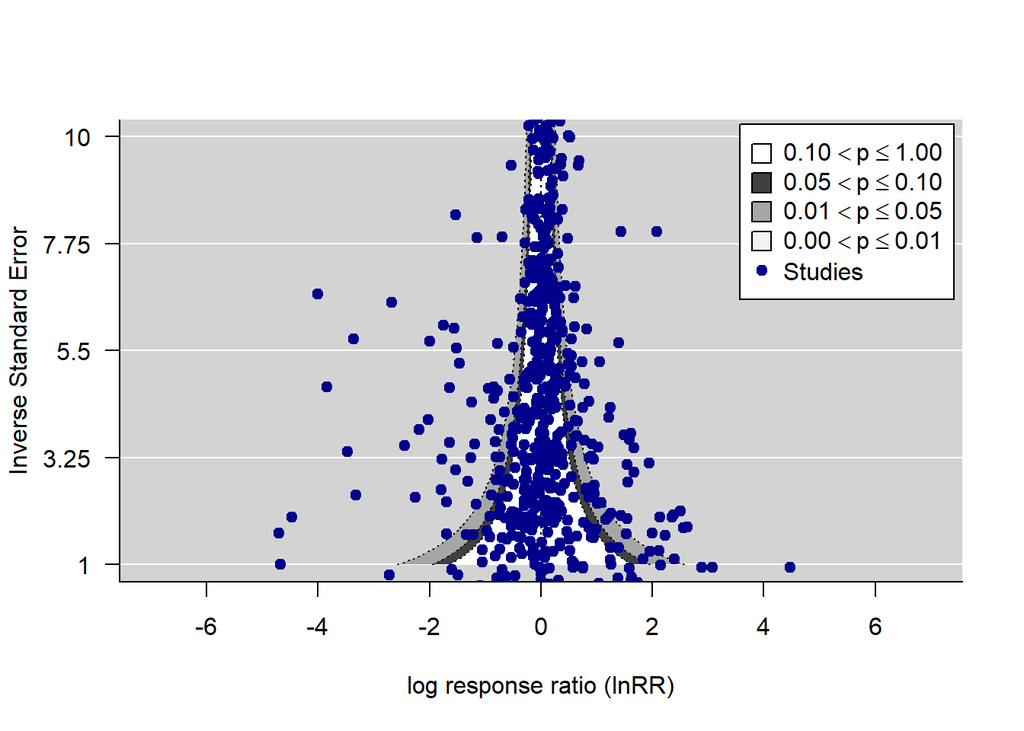

```r
# Lets make a funnel plot to visualize the data in relation to the precision
metafor::funnel(x = full$lnRR, vi = full$V_lnRR, yaxis = "seinv",xlim=c(-7,7),ylim=c(1,10),level = c(0.1, 0.05, 0.01), shade = c("white", "gray25", "gray 65","gray 95"),las = 1, xlab = "log response ratio (lnRR)", legend = TRUE,col="dark blue")
```

### Q8: Time-lag plot assessing how effect sizes may or may not have changed through time.

Plot Time-lag plot.

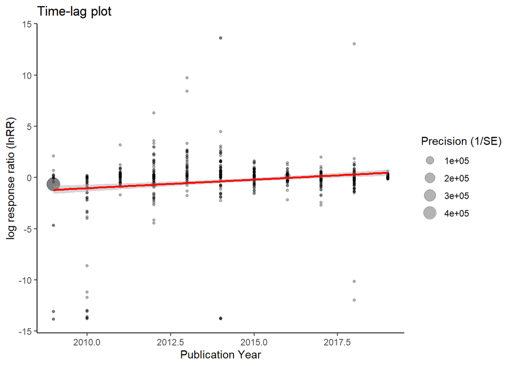

```r
ggplot(full, aes(y = lnRR, x = Year..online., size = 1/sqrt(V_lnRR))) + geom_point(alpha = 0.3) +
    geom_smooth(method = lm, col = "red", show.legend = FALSE) + labs(x = "Publication Year",
    y = "log response ratio (lnRR)", size = "Precision (1/SE)") +
    theme_classic()+ labs(title = "Time-lag plot")
```

From the Time-lag plot, it can be seen that the difference between the mean values of the experimental group and the control group (lnRR) has a significant positive correlation with the publication year. Therefore, the effect size showed an upward trend over time.

### Q9: Formal meta-regression model that includes year as a moderator (fixed effect) to test for time-lag bias.

Test for time-lag bias.

```r
meta_time <- rma.mv(lnRR ~ Year..online., V = V_lnRR, random = list(~1 | Study, ~1 | residual),
    test = "t", dfs = "contain", data = full)
summary(meta_time)
```

```
##
## Multivariate Meta-Analysis Model (k = 795; method: REML)
##
##     logLik    Deviance         AIC         BIC        AICc
## -1782.8090   3565.6180   3573.6180   3592.3213   3573.6688
##
## Variance Components:
##
##             estim    sqrt  nlvls  fixed    factor
## sigma^2.1  0.4017  0.6338     91     no     Study
## sigma^2.2  4.0496  2.0124    795     no  residual
##
## Test for Residual Heterogeneity:
## QE(df = 793) = 128790282.9931, p-val < .0001
##
## Test of Moderators (coefficient 2):
## F(df1 = 1, df2 = 89) = 7.6505, p-val = 0.0069
##
## Model Results:
##
##                 estimate       se     tval  df    pval      ci.lb     ci.ub
## intrcpt        -231.0645  83.4908  -2.7675  89  0.0069  -396.9589  -65.1701  **
## Year..online.     0.1146   0.0414   2.7660  89  0.0069     0.0323    0.1969  **
##
## ---
## Signif. codes:  0 '***' 0.001 '**' 0.01 '*' 0.05 '.' 0.1 ' ' 1
```

```r
r2_time <- orchaRd::r2_ml(meta_time)
r2_time
```

```
##    R2_marginal R2_conditional
##     0.02265587     0.11085961
```

### Q10: Formal meta-regression model that includes inverse sampling variance to test for file-drawer biases.

```r
rma.mv(lnRR ~ (1 / V_lnRR), V = V_lnRR, random = list(~1 | Study, ~1 | residual), test = "t", dfs = "contain", data = full)
```

```
##
## Multivariate Meta-Analysis Model (k = 795; method: REML)
##
## Variance Components:
##
##             estim    sqrt  nlvls  fixed    factor
## sigma^2.1  0.4792  0.6922     91     no     Study
## sigma^2.2  4.0497  2.0124    795     no  residual
##
## Test for Heterogeneity:
## Q(df = 794) = 736088678.9542, p-val < .0001
##
## Model Results:
##
## estimate      se     tval  df    pval    ci.lb   ci.ub
##  -0.1273  0.1140  -1.1162  90  0.2673  -0.3539  0.0993
##
## ---
## Signif. codes:  0 '***' 0.001 '**' 0.01 '*' 0.05 '.' 0.1 ' ' 1
```

### Q12: Identify any studies contributing to publication bias. How do your updated meta-analysis results compare with a meta-analysis by Clement et. al. (2022)? Are there any concerns about these studies? If so, describe using references to existing papers what concerns have been raised?

As can be seen in the article “Redundant meta-analyses are common in genetic epidemiology”, publishing similar, repeated meta-analyses in isolation, especially without significantly documenting associations with existing work, can be confusing, And add to the confusion in the scientific literature. Possible factors contributing to duplication include publishing pressure and the fact that authors or peer reviewers are not aware of what others are doing. In some areas, the proliferation of similar meta-analyses may also be attributed to special interest groups and may marginalize more legitimate or critical publications due to their sheer volume.